# SQ 031

## Shared Qs (031)

#### Question

1. [Integration](https://en.wikipedia.org/wiki/Integral) reverses differentiation. We will practice “undoing” the power rule by finding an [antiderivative](https://en.wikipedia.org/wiki/Antiderivative).

   Let $f(x)$ be an unknown polynomial. Its derivative is known.

   $$f'(x)={-15}x^{4}+{16}x^{3}-{18}x^{2}$$

   To undo the power rule, each term’s power is increased by 1, and then the coefficient is divided by the new power. This gets us most of the way.

   A (slightly annoying) complication occurs because adding any constant to $f(x)$ would not change its derivative, since the derivative of a constant is 0. This means there are infinitely many possible antiderivatives with a [constant of integration](https://en.wikipedia.org/wiki/Constant_of_integration) equaling any real number. If we know a single solution to $y=f(x)$ (a single point on the curve), then the constant of integration can be determined. In this case, let’s enforce the following condition:

   $$f(2)=-84$$

   We know the integral can be expressed as a polynomial with 4 terms, where $j>k>l$:

   $$f(x)=Jx^{j}+Kx^{k}+Lx^l+C$$

   Find the parameters.
   - $J=$
   - $j=$
   - $K=$
   - $k=$
   - $L=$
   - $l=$
   - $C=$

#### Solution

#### Question

2. [Integration](https://en.wikipedia.org/wiki/Integral) reverses differentiation. We will practice “undoing” the power rule by finding an [antiderivative](https://en.wikipedia.org/wiki/Antiderivative).

   Let $f(x)$ be an unknown polynomial. Its derivative is known.

   $$f'(x)={-10}x^{4}-{32}x^{3}-{4}{}$$

   To undo the power rule, each term’s power is increased by 1, and then the coefficient is divided by the new power. This gets us most of the way.

   A (slightly annoying) complication occurs because adding any constant to $f(x)$ would not change its derivative, since the derivative of a constant is 0. This means there are infinitely many possible antiderivatives with a [constant of integration](https://en.wikipedia.org/wiki/Constant_of_integration) equaling any real number. If we know a single solution to $y=f(x)$ (a single point on the curve), then the constant of integration can be determined. In this case, let’s enforce the following condition:

   $$f(-4)=11$$

   We know the integral can be expressed as a polynomial with 4 terms, where $j>k>l$:

   $$f(x)=Jx^{j}+Kx^{k}+Lx^l+C$$

   Find the parameters.
   - $J=$
   - $j=$
   - $K=$
   - $k=$
   - $L=$
   - $l=$
   - $C=$

#### Solution

#### Question

3. [Integration](https://en.wikipedia.org/wiki/Integral) reverses differentiation. We will practice “undoing” the power rule by finding an [antiderivative](https://en.wikipedia.org/wiki/Antiderivative).

   Let $f(x)$ be an unknown polynomial. Its derivative is known.

   $$f'(x)={-12}x^{3}+{24}x^{2}-{18}x^{}$$

   To undo the power rule, each term’s power is increased by 1, and then the coefficient is divided by the new power. This gets us most of the way.

   A (slightly annoying) complication occurs because adding any constant to $f(x)$ would not change its derivative, since the derivative of a constant is 0. This means there are infinitely many possible antiderivatives with a [constant of integration](https://en.wikipedia.org/wiki/Constant_of_integration) equaling any real number. If we know a single solution to $y=f(x)$ (a single point on the curve), then the constant of integration can be determined. In this case, let’s enforce the following condition:

   $$f(2)=-26$$

   We know the integral can be expressed as a polynomial with 4 terms, where $j>k>l$:

   $$f(x)=Jx^{j}+Kx^{k}+Lx^l+C$$

   Find the parameters.
   - $J=$
   - $j=$
   - $K=$
   - $k=$
   - $L=$
   - $l=$
   - $C=$

#### Solution

#### Question

4. [Integration](https://en.wikipedia.org/wiki/Integral) reverses differentiation. We will practice “undoing” the power rule by finding an [antiderivative](https://en.wikipedia.org/wiki/Antiderivative).

   Let $f(x)$ be an unknown polynomial. Its derivative is known.

   $$f'(x)={-35}x^{6}-{36}x^{5}+{35}x^{4}$$

   To undo the power rule, each term’s power is increased by 1, and then the coefficient is divided by the new power. This gets us most of the way.

   A (slightly annoying) complication occurs because adding any constant to $f(x)$ would not change its derivative, since the derivative of a constant is 0. This means there are infinitely many possible antiderivatives with a [constant of integration](https://en.wikipedia.org/wiki/Constant_of_integration) equaling any real number. If we know a single solution to $y=f(x)$ (a single point on the curve), then the constant of integration can be determined. In this case, let’s enforce the following condition:

   $$f(-2)=39$$

   We know the integral can be expressed as a polynomial with 4 terms, where $j>k>l$:

   $$f(x)=Jx^{j}+Kx^{k}+Lx^l+C$$

   Find the parameters.
   - $J=$
   - $j=$
   - $K=$
   - $k=$
   - $L=$
   - $l=$
   - $C=$

#### Solution

#### Question

5. [Integration](https://en.wikipedia.org/wiki/Integral) reverses differentiation. We will practice “undoing” the power rule by finding an [antiderivative](https://en.wikipedia.org/wiki/Antiderivative).

   Let $f(x)$ be an unknown polynomial. Its derivative is known.

   $$f'(x)={20}x^{4}-{12}x^{3}-{27}x^{2}$$

   To undo the power rule, each term’s power is increased by 1, and then the coefficient is divided by the new power. This gets us most of the way.

   A (slightly annoying) complication occurs because adding any constant to $f(x)$ would not change its derivative, since the derivative of a constant is 0. This means there are infinitely many possible antiderivatives with a [constant of integration](https://en.wikipedia.org/wiki/Constant_of_integration) equaling any real number. If we know a single solution to $y=f(x)$ (a single point on the curve), then the constant of integration can be determined. In this case, let’s enforce the following condition:

   $$f(2)=2$$

   We know the integral can be expressed as a polynomial with 4 terms, where $j>k>l$:

   $$f(x)=Jx^{j}+Kx^{k}+Lx^l+C$$

   Find the parameters.
   - $J=$
   - $j=$
   - $K=$
   - $k=$
   - $L=$
   - $l=$
   - $C=$

#### Solution

#### Question

6. A [definite integral](https://en.wikipedia.org/wiki/Integral) can be used to express the area under a curve. For example, say we wanted to find the area under $f(x)=x^{}-x^{7}$ between $x=0.43$ and $x=0.81$. Let’s draw a picture.

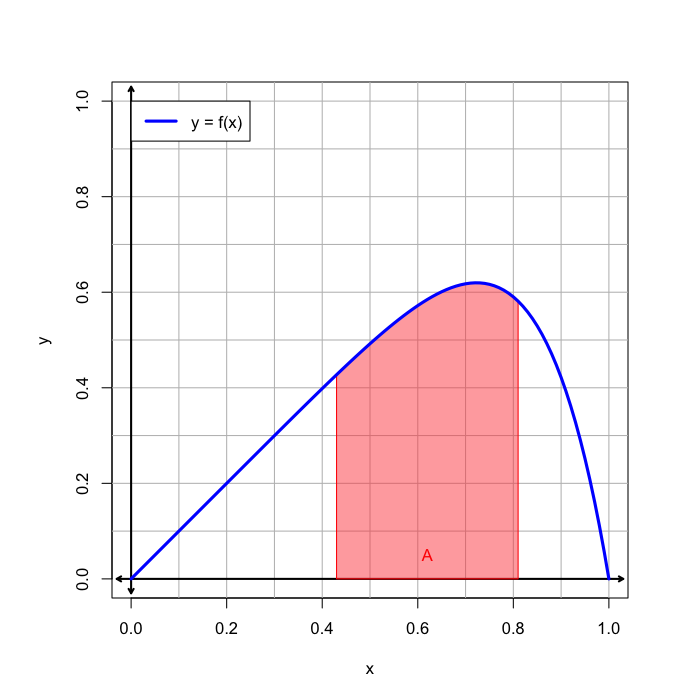

   The area equals the definite integral of the function on interval [0.43, 0.81].

   $$A ~=~ \int_{0.43}^{0.81} \left(x^{}-x^{7} \right)~dx$$

   This definite integral can be evaluated from an antiderivative of $f(x)$. Let $g(x)$ be an antiderivative of $f(x)$ such that $g'(x)=f(x)$.

   $$A~=~g(0.81)-g(0.43)$$

   Find the area. The tolerance is $\pm 0.001$.

#### Solution

#### Question

7. A [definite integral](https://en.wikipedia.org/wiki/Integral) can be used to express the area under a curve. For example, say we wanted to find the area under $f(x)=x^{3}-x^{9}$ between $x=0.51$ and $x=0.8$. Let’s draw a picture.

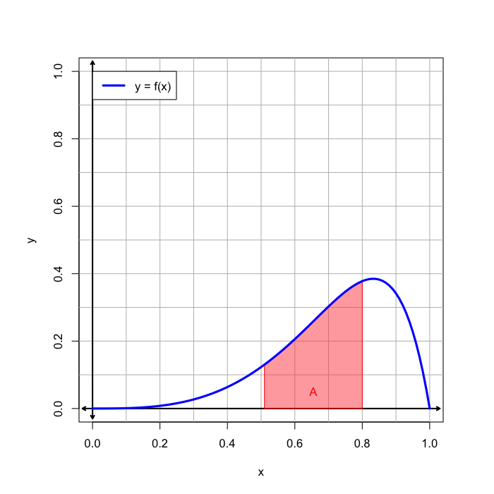

   The area equals the definite integral of the function on interval [0.51, 0.8].

   $$A ~=~ \int_{0.51}^{0.8} \left(x^{3}-x^{9} \right)~dx$$

   This definite integral can be evaluated from an antiderivative of $f(x)$. Let $g(x)$ be an antiderivative of $f(x)$ such that $g'(x)=f(x)$.

   $$A~=~g(0.8)-g(0.51)$$

   Find the area. The tolerance is $\pm 0.001$.

#### Solution

#### Question

8. A [definite integral](https://en.wikipedia.org/wiki/Integral) can be used to express the area under a curve. For example, say we wanted to find the area under $f(x)=x^{}-x^{6}$ between $x=0.49$ and $x=0.87$. Let’s draw a picture.

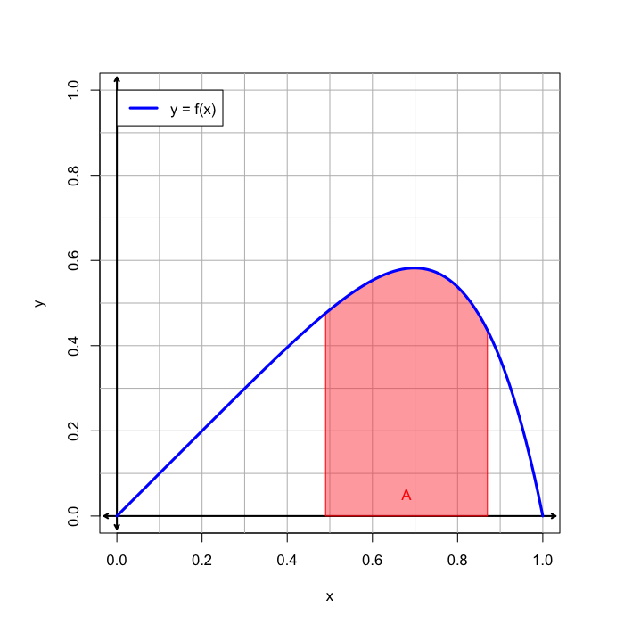

   The area equals the definite integral of the function on interval [0.49, 0.87].

   $$A ~=~ \int_{0.49}^{0.87} \left(x^{}-x^{6} \right)~dx$$

   This definite integral can be evaluated from an antiderivative of $f(x)$. Let $g(x)$ be an antiderivative of $f(x)$ such that $g'(x)=f(x)$.

   $$A~=~g(0.87)-g(0.49)$$

   Find the area. The tolerance is $\pm 0.001$.

#### Solution

#### Question

9. A [definite integral](https://en.wikipedia.org/wiki/Integral) can be used to express the area under a curve. For example, say we wanted to find the area under $f(x)=x^{}-x^{5}$ between $x=0.54$ and $x=0.8$. Let’s draw a picture.

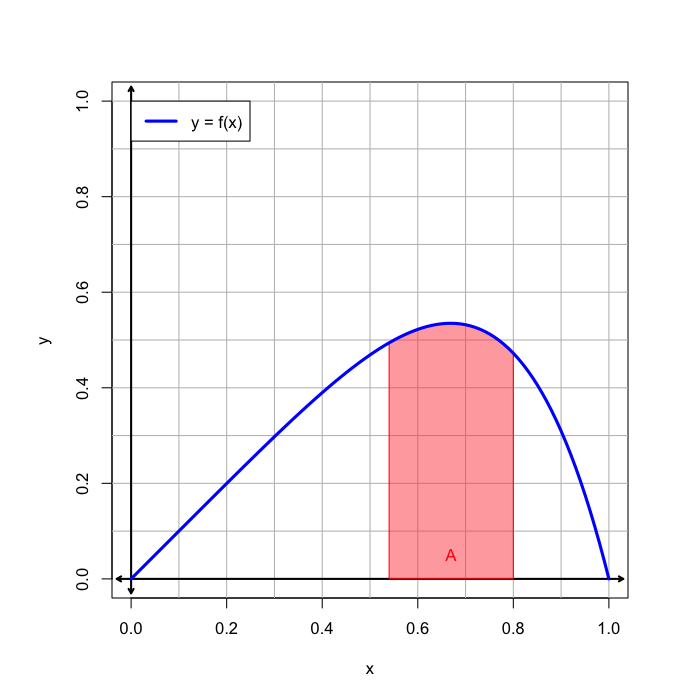

   The area equals the definite integral of the function on interval [0.54, 0.8].

   $$A ~=~ \int_{0.54}^{0.8} \left(x^{}-x^{5} \right)~dx$$

   This definite integral can be evaluated from an antiderivative of $f(x)$. Let $g(x)$ be an antiderivative of $f(x)$ such that $g'(x)=f(x)$.

   $$A~=~g(0.8)-g(0.54)$$

   Find the area. The tolerance is $\pm 0.001$.

#### Solution

#### Question

10. A [definite integral](https://en.wikipedia.org/wiki/Integral) can be used to express the area under a curve. For example, say we wanted to find the area under $f(x)=x^{3}-x^{7}$ between $x=0.56$ and $x=0.85$. Let’s draw a picture.

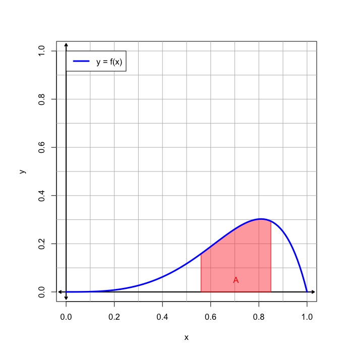

    The area equals the definite integral of the function on interval [0.56, 0.85].

    $$A ~=~ \int_{0.56}^{0.85} \left(x^{3}-x^{7} \right)~dx$$

    This definite integral can be evaluated from an antiderivative of $f(x)$. Let $g(x)$ be an antiderivative of $f(x)$ such that $g'(x)=f(x)$.

    $$A~=~g(0.85)-g(0.56)$$

    Find the area. The tolerance is $\pm 0.001$.

#### Solution

#### Question

11. A particle moves up and down along a 1-dimensional path. It’s acceleration ($a(t)$ in $\mathrm{\frac{m}{s^2}}$) is a function of time ($t$ in seconds).

    $$a(t)=-48t+12$$

    The particle’s velocity is also a function of time. Also, $v(0)=4$.

    $$v(t) ~=~ 4 + \int_{0}^{t}a(t)\,dt$$

    The particle’s position is also a function of time. Also, $x(0)=4$.

    $$x(t) ~=~ 4 + \int_{0}^{t}v(t)\,dt$$

    Evaluate position, velocity, and acceleration at $t=0$, $t=1$, and $t=2$.

    | t | y(t) | v(t) | a(t) |
    | --- | --- | --- | --- |
    | 0 |  |  |  |
    | 1 |  |  |  |
    | 2 |  |  |  |

#### Solution

#### Question

12. A particle moves up and down along a 1-dimensional path. It’s acceleration ($a(t)$ in $\mathrm{\frac{m}{s^2}}$) is a function of time ($t$ in seconds).

    $$a(t)=-36t+10$$

    The particle’s velocity is also a function of time. Also, $v(0)=8$.

    $$v(t) ~=~ 8 + \int_{0}^{t}a(t)\,dt$$

    The particle’s position is also a function of time. Also, $x(0)=2$.

    $$x(t) ~=~ 2 + \int_{0}^{t}v(t)\,dt$$

    Evaluate position, velocity, and acceleration at $t=0$, $t=1$, and $t=2$.

    | t | y(t) | v(t) | a(t) |
    | --- | --- | --- | --- |
    | 0 |  |  |  |
    | 1 |  |  |  |
    | 2 |  |  |  |

#### Solution

#### Question

13. A particle moves up and down along a 1-dimensional path. It’s acceleration ($a(t)$ in $\mathrm{\frac{m}{s^2}}$) is a function of time ($t$ in seconds).

    $$a(t)=-48t+20$$

    The particle’s velocity is also a function of time. Also, $v(0)=6$.

    $$v(t) ~=~ 6 + \int_{0}^{t}a(t)\,dt$$

    The particle’s position is also a function of time. Also, $x(0)=-1$.

    $$x(t) ~=~ -1 + \int_{0}^{t}v(t)\,dt$$

    Evaluate position, velocity, and acceleration at $t=0$, $t=1$, and $t=2$.

    | t | y(t) | v(t) | a(t) |
    | --- | --- | --- | --- |
    | 0 |  |  |  |
    | 1 |  |  |  |
    | 2 |  |  |  |

#### Solution

#### Question

14. A particle moves up and down along a 1-dimensional path. It’s acceleration ($a(t)$ in $\mathrm{\frac{m}{s^2}}$) is a function of time ($t$ in seconds).

    $$a(t)=-36t+4$$

    The particle’s velocity is also a function of time. Also, $v(0)=8$.

    $$v(t) ~=~ 8 + \int_{0}^{t}a(t)\,dt$$

    The particle’s position is also a function of time. Also, $x(0)=10$.

    $$x(t) ~=~ 10 + \int_{0}^{t}v(t)\,dt$$

    Evaluate position, velocity, and acceleration at $t=0$, $t=1$, and $t=2$.

    | t | y(t) | v(t) | a(t) |
    | --- | --- | --- | --- |
    | 0 |  |  |  |
    | 1 |  |  |  |
    | 2 |  |  |  |

#### Solution

#### Question

15. A particle moves up and down along a 1-dimensional path. It’s acceleration ($a(t)$ in $\mathrm{\frac{m}{s^2}}$) is a function of time ($t$ in seconds).

    $$a(t)=-54t+14$$

    The particle’s velocity is also a function of time. Also, $v(0)=9$.

    $$v(t) ~=~ 9 + \int_{0}^{t}a(t)\,dt$$

    The particle’s position is also a function of time. Also, $x(0)=2$.

    $$x(t) ~=~ 2 + \int_{0}^{t}v(t)\,dt$$

    Evaluate position, velocity, and acceleration at $t=0$, $t=1$, and $t=2$.

    | t | y(t) | v(t) | a(t) |
    | --- | --- | --- | --- |
    | 0 |  |  |  |
    | 1 |  |  |  |
    | 2 |  |  |  |

#### Solution

#### Question

16. A 3D shape’s base is the 2D region enclosed by $y=0$ and $y=f(x)=x^{0.8}-x^{5.5}$ on the $xy$ plane. For every plane perpendicular to the $x$ axis, with $0<x<1$, there is a square cross section.

    I have attempted to draw this below.

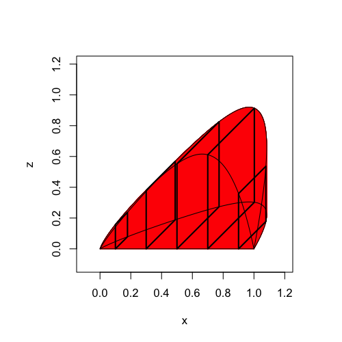

    And here is a spinning animation. Does that help?

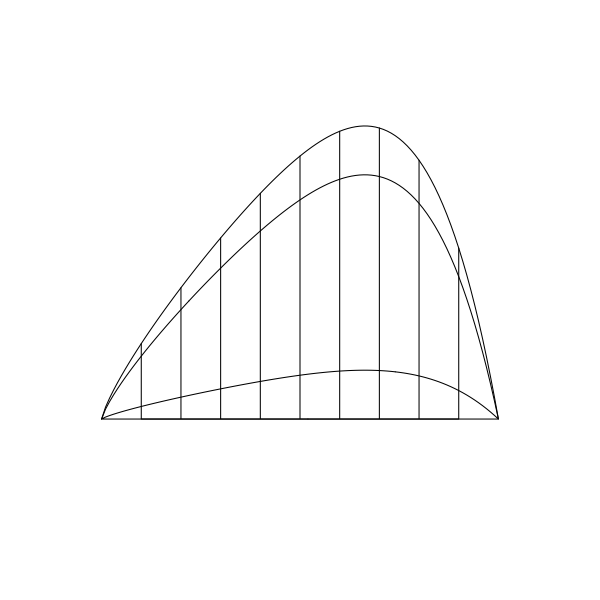

    Find the volume of the shape; the tolerance is $\pm 0.001$ cubic units. You might find [this video](https://www.khanacademy.org/math/ap-calculus-ab/ab-applications-of-integration-new/ab-8-7/v/volume-with-cross-sections-intro) helpful. The general topic is “[volume from cross sections](https://en.wikibooks.org/wiki/Calculus/Volume)”; you might try a variety of resources by searching this phrase in your favorite search engine.

#### Solution

#### Question

17. A 3D shape’s base is the 2D region enclosed by $y=0$ and $y=f(x)=x^{0.5}-x^{2.4}$ on the $xy$ plane. For every plane perpendicular to the $x$ axis, with $0<x<1$, there is a square cross section.

    I have attempted to draw this below.

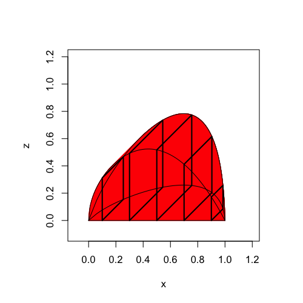

    And here is a spinning animation. Does that help?

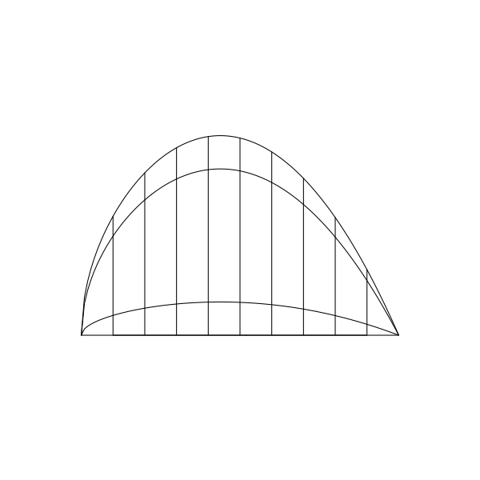

    Find the volume of the shape; the tolerance is $\pm 0.001$ cubic units. You might find [this video](https://www.khanacademy.org/math/ap-calculus-ab/ab-applications-of-integration-new/ab-8-7/v/volume-with-cross-sections-intro) helpful. The general topic is “[volume from cross sections](https://en.wikibooks.org/wiki/Calculus/Volume)”; you might try a variety of resources by searching this phrase in your favorite search engine.

#### Solution

#### Question

18. A 3D shape’s base is the 2D region enclosed by $y=0$ and $y=f(x)=x^{0.7}-x^{8.6}$ on the $xy$ plane. For every plane perpendicular to the $x$ axis, with $0<x<1$, there is a square cross section.

    I have attempted to draw this below.

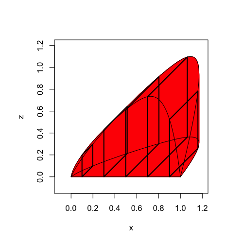

    And here is a spinning animation. Does that help?

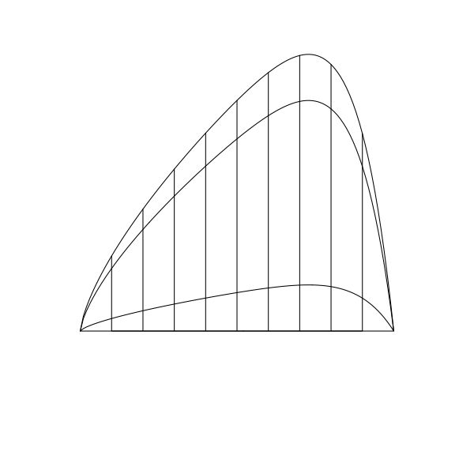

    Find the volume of the shape; the tolerance is $\pm 0.001$ cubic units. You might find [this video](https://www.khanacademy.org/math/ap-calculus-ab/ab-applications-of-integration-new/ab-8-7/v/volume-with-cross-sections-intro) helpful. The general topic is “[volume from cross sections](https://en.wikibooks.org/wiki/Calculus/Volume)”; you might try a variety of resources by searching this phrase in your favorite search engine.

#### Solution

#### Question

19. A 3D shape’s base is the 2D region enclosed by $y=0$ and $y=f(x)=x^{1.7}-x^{9.3}$ on the $xy$ plane. For every plane perpendicular to the $x$ axis, with $0<x<1$, there is a square cross section.

    I have attempted to draw this below.

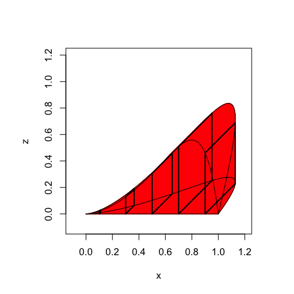

    And here is a spinning animation. Does that help?

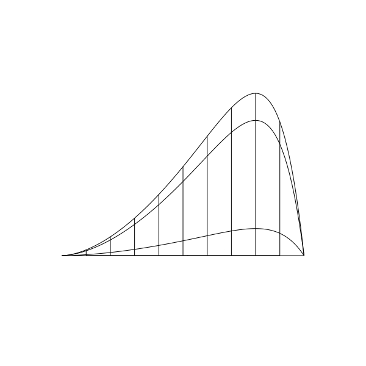

    Find the volume of the shape; the tolerance is $\pm 0.001$ cubic units. You might find [this video](https://www.khanacademy.org/math/ap-calculus-ab/ab-applications-of-integration-new/ab-8-7/v/volume-with-cross-sections-intro) helpful. The general topic is “[volume from cross sections](https://en.wikibooks.org/wiki/Calculus/Volume)”; you might try a variety of resources by searching this phrase in your favorite search engine.

#### Solution

#### Question

20. A 3D shape’s base is the 2D region enclosed by $y=0$ and $y=f(x)=x^{1.1}-x^{3.6}$ on the $xy$ plane. For every plane perpendicular to the $x$ axis, with $0<x<1$, there is a square cross section.

    I have attempted to draw this below.

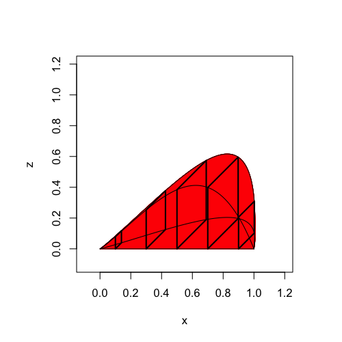

    And here is a spinning animation. Does that help?

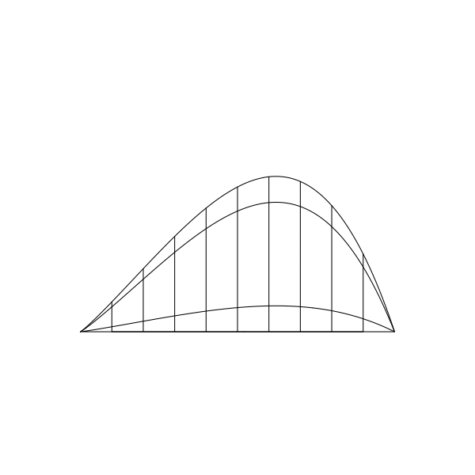

    Find the volume of the shape; the tolerance is $\pm 0.001$ cubic units. You might find [this video](https://www.khanacademy.org/math/ap-calculus-ab/ab-applications-of-integration-new/ab-8-7/v/volume-with-cross-sections-intro) helpful. The general topic is “[volume from cross sections](https://en.wikibooks.org/wiki/Calculus/Volume)”; you might try a variety of resources by searching this phrase in your favorite search engine.

#### Solution